# Simulation exercise in **Genomik und Bioinformatik**

## Part D) Programming - Classification with feature selection

**1. Compute classifiers:**

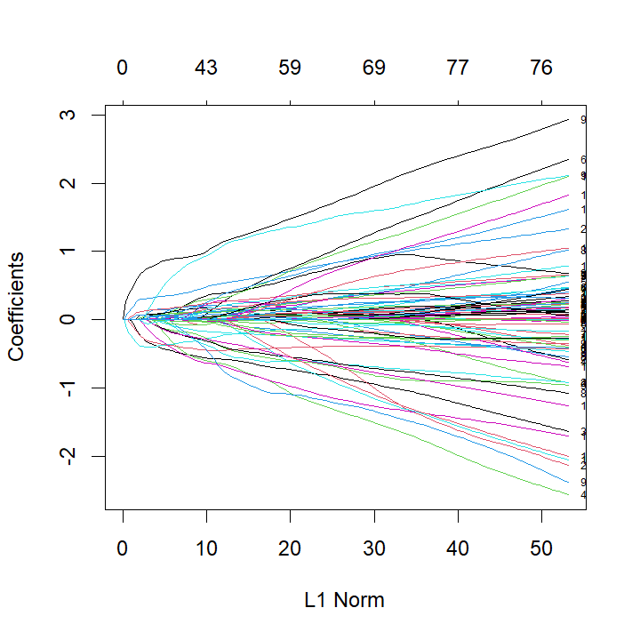

```r
> library(glmnet)
>
> load(file= "C:/Users/aleX/Kurse/genomik/Blatt11/split_lenz.rda")
>
> alpha1.fit <-
+   glmnet(mat.train, pdat.train$risk, type.measure="mse", alpha=1, family="binomial")
>
>
> plot(alpha1.fit, label=TRUE) #vignette("glmnet", package="glmnet")
```

**Answer 1:**  
The paramter *family* was set to `binominal` since the phenoData consists only of two labels, namely ‘high’ and ‘low’.  
`plot()` showes the line plots for the 20.000 coefficients (one coefficient for each gene/feature) and their decline with increasing lambda. The top axis indicates the number of non-zero coefficients of the features. On the far left of the plot lambda is maximal, which results in a maximal regularization and thus all coefficients become zero (no non-zero coefficients).

**2. Evaluate classifiers:**

```r
> alpha1.predicted <-
+   predict(alpha1.fit, newx=mat.val, type='class') #test data
>
> alpha2.predicted <-
+   predict(alpha1.fit, newx=mat.train, type='class') #training data
>
> print(alpha1.predicted[1:3,1:5]) #prediction for first three genes for five different lambdas
```

```
##           s0     s1     s2     s3     s4
## GSM275084 "high" "high" "low"  "low"  "low"
## GSM275089 "high" "high" "high" "low"  "low"
## GSM275090 "high" "high" "high" "high" "high"
```

```r
> #Error rates calculated for EACH classifier
> errors <- list(train_error = c(), test_error = c())
> for (lambda in 1:dim(alpha1.predicted)[2]){
+
+   myError_te <- mean(pdat.val$risk != alpha1.predicted[, lambda]) #test
+   errors$test_error[lambda] <- myError_te
+
+   myError_tr <- mean(pdat.train$risk != alpha2.predicted[, lambda]) #train
+   errors$train_error[lambda] <- myError_tr
+ }
>
> lowest_error_test_ind <- order(errors$test_error, decreasing=FALSE)[1] #33
> print(paste("Smallest test error", round(errors$test_error[lowest_error_test_ind],4), "with lambda:", round(alpha1.fit$lambda[lowest_error_test_ind],4)))
```

```
## [1] "Smallest test error 0.3097 with lambda: 0.05"
```

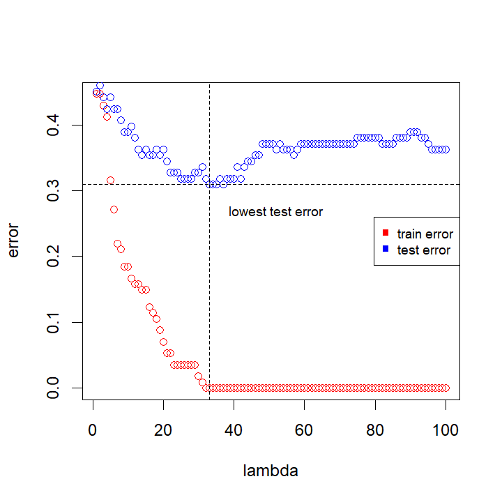

```r
> {plot(errors$train_error, col="red", ylab="error", xlab="lambda")
+ points(errors$test_error, col="blue")
+ legend("right", legend=c("train error", "test error"), col=c("red","blue"), pch=15, cex=0.8)
+ abline(h=errors$test_error[lowest_error_test_ind], lty=2)
+ abline(v=lowest_error_test_ind, lty=2)
+ text(x = 52, y = 0.27, label = "lowest test error", cex=0.8)}
```

```r
> print(paste("Error rate with only one non-zero coefficient:", round(errors$test_error[alpha1.fit$df == 1],4)))
```

```
## [1] "Error rate with only one non-zero coefficient: 0.4602"
```

```r
> highest_df_index <- order(alpha1.fit$df, decreasing=TRUE)[1]
> highest_df <- alpha1.fit$df[highest_df_index]
>
> print(paste("Error rate for maximal nonzero coeff. (df=", highest_df,") :", round(min(errors$test_error[alpha1.fit$df == highest_df]),3)))
```

```
## [1] "Error rate for maximal nonzero coeff. (df= 77 ) : 0.363"
```

**Answer (2a):**  
Error rate for one gene:  
With only one coefficient/gene the fit model is not complex enough to fit the complex behavior expected from our gene data. It can therefore not divide/predict the classes well. Error rate for maximal number of features:  
If too many coefficients/features are used to train our model, then we get a very good result for the training data but the model fails to learn the general underlying data and therefore cannot fit new data very well. This is called overfitting.

```r
> #sensitivity <- "true positives/ (true positives+false negatives)"
> tp <- 0 #true positive
> fn <- 0 #false negative
> #specificity <- "true negatives/ (true negatives+false positives)"
> tn <- 0
> fp <- 0
> for (i in 1:(dim(alpha1.predicted)[1])){
+
+   if (alpha1.predicted[i,lowest_error_test_ind] == "high"){
+     if (pdat.val$risk[i] == "high"){
+       tp <- tp + 1
+     } else {
+       fp <- fp + 1
+     }
+   }
+   else {
+     if (pdat.val$risk[i] == "high"){
+       fn <- fn + 1
+     } else {
+       tn <- tn +1
+     }
+   }
+ }
>
> sensitivity <- tp/(tp+fn)
> specificity <- tn/(tn+fp)
> print(paste("Sensitivity:", round(sensitivity,3)))
```

```
## [1] "Sensitivity: 0.774"
```

```r
> print(paste("Specificity:", round(specificity,3)))
```

```
## [1] "Specificity: 0.588"
```

**Answer (2b):**  
The error rate does not explain where the error comes from. It could be both from false negatives or false positives. This is were sensitivity and specificity are more helpful.  
Explanation of sensitivity and specificity on the example of a Corona test:  
A test that is highly sensitive will flag almost everyone who has the disease and not generate many false-negative results.  
A high-specificity test will correctly rule out almost everyone who doesn’t have the disease and won’t generate many false-positive results.